# Self-Guided R Toolkit

Pod 1 • Reference for continued learning during self-guided fellowship weeks

Author

Madeline Ratoza, PT, DPT, PhD

# Use this toolkit after the lesson

This is a reference for your self-guided work, not a reading assignment to finish in one sitting. Choose the section that solves your current problem. Keep your first project small: one question, one summary, one figure, and an explanation you can reproduce.

| If you need to… | Start with… |
| --- | --- |
| Begin a project | Project organization and the reusable analysis plan |
| Understand your data | Data dictionary and data checks |
| Choose or learn a statistical method | Statistics guide and linked resources |
| Get unstuck | Troubleshooting and the help request template |
| Keep making progress | Work-session routine and progress log |

## Set up once

Open this QMD in an RStudio project. To render it, use R, Quarto, and the R packages `knitr` and `rmarkdown`. If needed, install those packages once in the Console with `install.packages(c("knitr", "rmarkdown"))`. Run chunks from top to bottom or click Render. Examples use data included in R and base R functions; no dataset download is required.

```r
# This toolkit runs independently of the live lesson.
flowers <- iris
```

## Project organization

Use one RStudio project per analysis. Keep original data unchanged, save cleaning decisions in code, and use project-relative paths. A small project can begin with an `analysis.qmd`, a `data-raw/` folder, and an `outputs/` folder. Add a README, data dictionary, and decision log as the work grows.

Decide what one row represents. Put each variable in its own column, use consistent units, and document missing-value codes. Repeated measurements need an ID and a time or visit variable. An identical row is a reason to investigate, not an automatic reason to delete it.

## A reusable analysis plan

Copy this section into a new QMD before writing analysis code.

| Item | Fill in before analysis |
| --- | --- |
| Purpose and audience | Who needs this result, and why? |
| Question | What specific comparison, description, or association? |
| Design | Observational or experimental? Cross-sectional or longitudinal? |
| Unit of observation | Person, visit, course, location, or another unit? |
| Data source | Where, when, and how were data collected? |
| Variables | Outcome, predictors/groups, units, coding, and possible confounders |
| Inclusion rules | Which observations are eligible, and why? |
| Data checks | Missingness, types, ranges, duplicate keys, group sizes |
| Planned outputs | Which table and plot answer the question? |
| Statistical method, if needed | Why is it appropriate for the design and data? |
| Assumptions and diagnostics | How will I check them? What if they are not reasonable? |
| Interpretation limits | Bias, confounding, precision, and generalizability |
| Completion criteria | What is enough for this version? |

Distinguish planned analyses from questions discovered while exploring. If you change the plan after seeing the data, document why.

## A data dictionary starter

| Variable | Meaning | Type | Unit or levels | Missing code |
| --- | --- | --- | --- | --- |
| `person_id` | Stable participant identifier | Character | One ID per person | Should not be missing |
| `time` | Measurement occasion | Factor | baseline, followup | `NA` |
| `score` | Name and definition of measure | Numeric | Specify scale and valid range | `NA` |

An identifier that contains digits may still belong in a character column. A coded category such as 1/2/3 is not automatically a continuous numeric measurement.

## Data checks to keep nearby

```r
# These run on today's example. Replace flowers in your own project.
names(flowers)
```

```
[1] "Sepal.Length" "Sepal.Width"  "Petal.Length" "Petal.Width"  "Species"
```

```r
str(flowers)
```

```
'data.frame':   150 obs. of  5 variables:
 $ Sepal.Length: num  5.1 4.9 4.7 4.6 5 5.4 4.6 5 4.4 4.9 ...
 $ Sepal.Width : num  3.5 3 3.2 3.1 3.6 3.9 3.4 3.4 2.9 3.1 ...
 $ Petal.Length: num  1.4 1.4 1.3 1.5 1.4 1.7 1.4 1.5 1.4 1.5 ...
 $ Petal.Width : num  0.2 0.2 0.2 0.2 0.2 0.4 0.3 0.2 0.2 0.1 ...
 $ Species     : Factor w/ 3 levels "setosa","versicolor",..: 1 1 1 1 1 1 1 1 1 1 ...
```

```r
summary(flowers)
```

```
  Sepal.Length    Sepal.Width     Petal.Length    Petal.Width
 Min.   :4.300   Min.   :2.000   Min.   :1.000   Min.   :0.100
 1st Qu.:5.100   1st Qu.:2.800   1st Qu.:1.600   1st Qu.:0.300
 Median :5.800   Median :3.000   Median :4.350   Median :1.300
 Mean   :5.843   Mean   :3.057   Mean   :3.758   Mean   :1.199
 3rd Qu.:6.400   3rd Qu.:3.300   3rd Qu.:5.100   3rd Qu.:1.800
 Max.   :7.900   Max.   :4.400   Max.   :6.900   Max.   :2.500
       Species
 setosa    :50
 versicolor:50
 virginica :50
```

```r
colSums(is.na(flowers))
```

```
Sepal.Length  Sepal.Width Petal.Length  Petal.Width      Species
           0            0            0            0            0
```

```r
sum(duplicated(flowers))  # identical rows: investigate before deleting
```

```
[1] 1
```

For a dataset with an ID, check `anyDuplicated(my_data$person_id)` only if each person should appear once. For repeated visits, check the combined key, for example `anyDuplicated(my_data[c("person_id", "time")])`.

```r
# Import recipe: adapt the filename and missing-value codes to your data.
my_data <- read.csv("data-raw/survey.csv",
                    na.strings = c("", "NA"))
str(my_data)
# Check the imported types before converting columns.
# Never convert a factor directly with as.numeric() to recover its labels.
```

## Statistics: where should I start?

Start with the question, measurement scale, and study design. This table is a navigation aid, not an automatic test selector. Repeated observations, clustered samples, confounding, and complex designs may require different models.

| Your question | Possible starting point in R | Check before using |
| --- | --- | --- |
| What does this variable look like? | `summary()`, `table()`, `hist()` | Missingness, units, distribution, denominators |
| How do two independent groups differ on a numeric outcome? | `t.test(y ~ group)`; Welch is the default | Independent observations, outliers, distribution/sample sizes; mean difference is the target |
| How do paired numeric measurements differ? | `t.test(after, before, paired = TRUE)` | Correct matching; distribution of within-person differences; independent pairs |
| How do three or more independent groups differ? | `oneway.test(y ~ group)` | Independent observations, group distributions; follow-up comparisons need a plan |
| Are two numeric variables associated? | `cor.test(x, y)` or `cor.test(x, y, method = "spearman")` | Independent pairs; linear pattern for Pearson, monotonic pattern for Spearman; inspect outliers |
| Are two categorical variables associated? | `chisq.test(table(a, b))` | Independent observations and adequate expected cell counts; consider `fisher.test()` for small tables |
| How does a numeric outcome relate to predictors? | `lm(y ~ x + group)` | Functional form, residuals, independence, variance, influential points, confounding |
| Is the outcome binary, repeated, clustered, or time-to-event? | Find a design-specific guide or consult a statistician | Outcome structure and dependence determine the model |

Nonparametric methods are not assumption-free. A rank-based group test does not universally test a difference in medians. Do not choose a method solely from a normality test, and do not try multiple tests to find a preferred p-value.

### Recipe 1: correlation

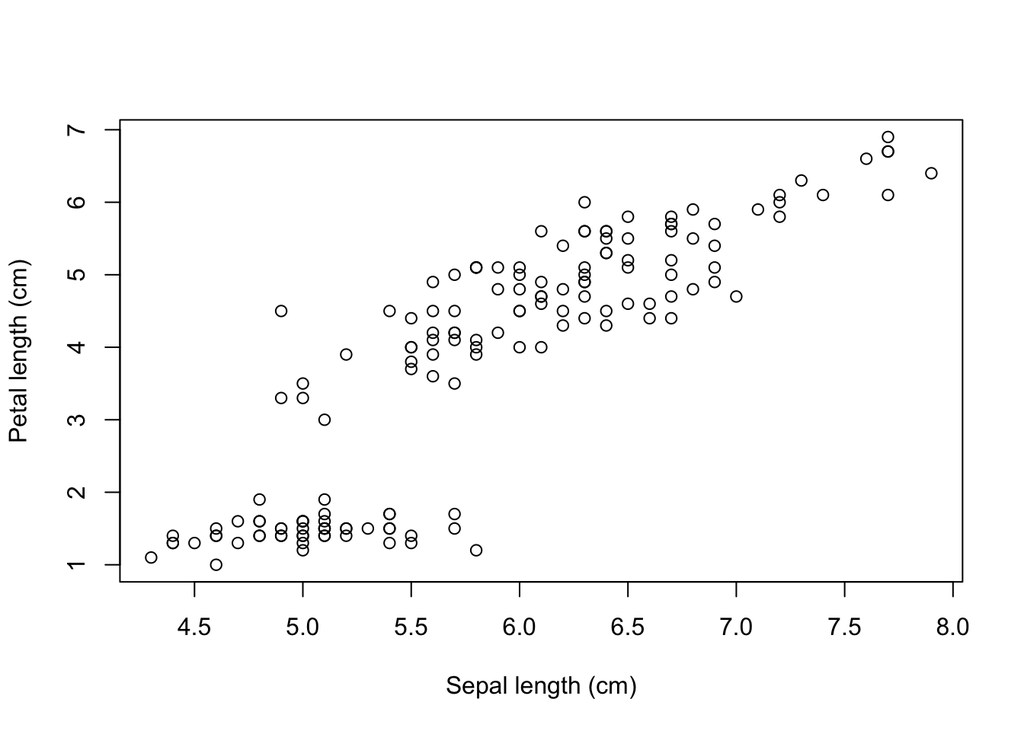

```r
# Explore first. This pooled example combines three species.
plot(flowers$Sepal.Length, flowers$Petal.Length,
     xlab = "Sepal length (cm)", ylab = "Petal length (cm)")
```

```r
association <- cor.test(flowers$Sepal.Length, flowers$Petal.Length,
                        method = "pearson")
association$estimate
```

```
      cor
0.8717538
```

```r
association$conf.int
```

```
[1] 0.8270363 0.9055080
attr(,"conf.level")
[1] 0.95
```

```r
association$p.value
```

```
[1] 1.038667e-47
```

Report the correlation estimate, uncertainty, number of complete pairs, and context. Here, species differences may contribute to the pooled association. Correlation does not establish a causal effect.

For a monotonic rank association, use `cor.test(x, y, method = "spearman", exact = FALSE)`; `exact = FALSE` requests an approximate p-value and is useful when ties are present. Choose based on the question and data, not which p-value is smaller.

### Recipe 2: compare two independent groups

```r
# Restrict to two species for this two-group illustration.
two_species <- droplevels(subset(flowers,
                         Species %in% c("setosa", "versicolor")))
comparison <- t.test(Sepal.Length ~ Species, data = two_species)
comparison
```

```
    Welch Two Sample t-test

data:  Sepal.Length by Species
t = -10.521, df = 86.538, p-value < 2.2e-16
alternative hypothesis: true difference in means between group setosa and group versicolor is not equal to 0
95 percent confidence interval:
 -1.1057074 -0.7542926
sample estimates:
    mean in group setosa mean in group versicolor
                   5.006                    5.936
```

```r
comparison$estimate
```

```
    mean in group setosa mean in group versicolor
                   5.006                    5.936
```

```r
comparison$conf.int
```

```
[1] -1.1057074 -0.7542926
attr(,"conf.level")
[1] 0.95
```

The output names the group means and gives a confidence interval for their difference. Check the order of the groups before describing the sign. Welch’s test allows unequal variances, but independence and a reasonable sampling/model basis still matter. This is a syntax example, not a recommendation to test every pair of species.

### Recipe 3: paired measurements

```r
# Synthetic practice data: each row is one correctly matched person.
paired_data <- data.frame(
  id = 1:10,
  before = c(12, 15, 11, 18, 13, 16, 14, 10, 17, 15),
  after  = c(14, 16, 11, 21, 15, 17, 17, 12, 18, 19)
)
paired_data$change <- paired_data$after - paired_data$before
summary(paired_data$change)
```

```
   Min. 1st Qu.  Median    Mean 3rd Qu.    Max.
   0.00    1.00    2.00    1.90    2.75    4.00
```

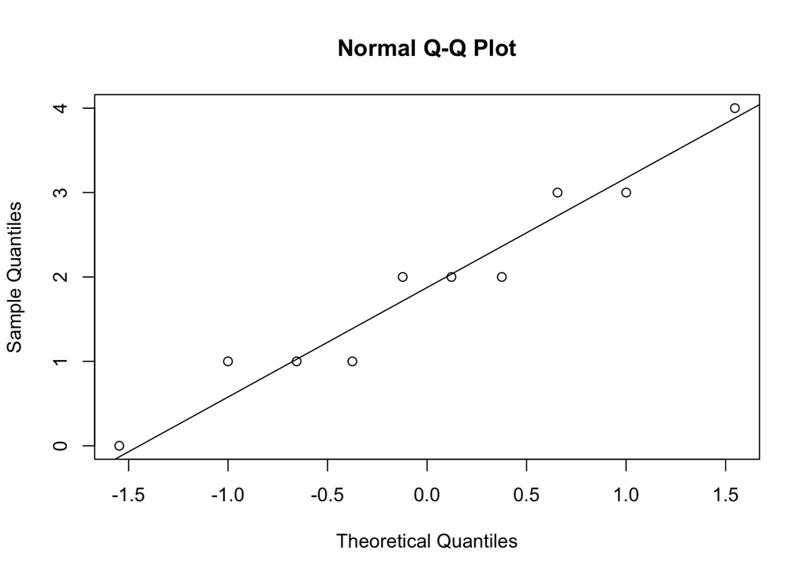

```r
qqnorm(paired_data$change)
qqline(paired_data$change)
```

```r
t.test(paired_data$after, paired_data$before, paired = TRUE)
```

```
    Paired t-test

data:  paired_data$after and paired_data$before
t = 5.0186, df = 9, p-value = 0.0007205
alternative hypothesis: true mean difference is not equal to 0
95 percent confidence interval:
 1.043561 2.756439
sample estimates:
mean difference
            1.9
```

Inspect the differences, rather than testing each time point separately. This small synthetic sample is for learning code. A before/after difference alone does not show that an intervention caused the change.

### Recipe 4: a first linear model

```r
model <- lm(Sepal.Length ~ Petal.Length, data = flowers)
summary(model)
```

```
Call:
lm(formula = Sepal.Length ~ Petal.Length, data = flowers)

Residuals:
     Min       1Q   Median       3Q      Max
-1.24675 -0.29657 -0.01515  0.27676  1.00269

Coefficients:
             Estimate Std. Error t value Pr(>|t|)
(Intercept)   4.30660    0.07839   54.94   <2e-16 ***
Petal.Length  0.40892    0.01889   21.65   <2e-16 ***
---
Signif. codes:  0 '***' 0.001 '**' 0.01 '*' 0.05 '.' 0.1 ' ' 1

Residual standard error: 0.4071 on 148 degrees of freedom
Multiple R-squared:   0.76, Adjusted R-squared:  0.7583
F-statistic: 468.6 on 1 and 148 DF,  p-value: < 2.2e-16
```

```r
confint(model)
```

```
                 2.5 %    97.5 %
(Intercept)  4.1516972 4.4615096
Petal.Length 0.3715907 0.4462539
```

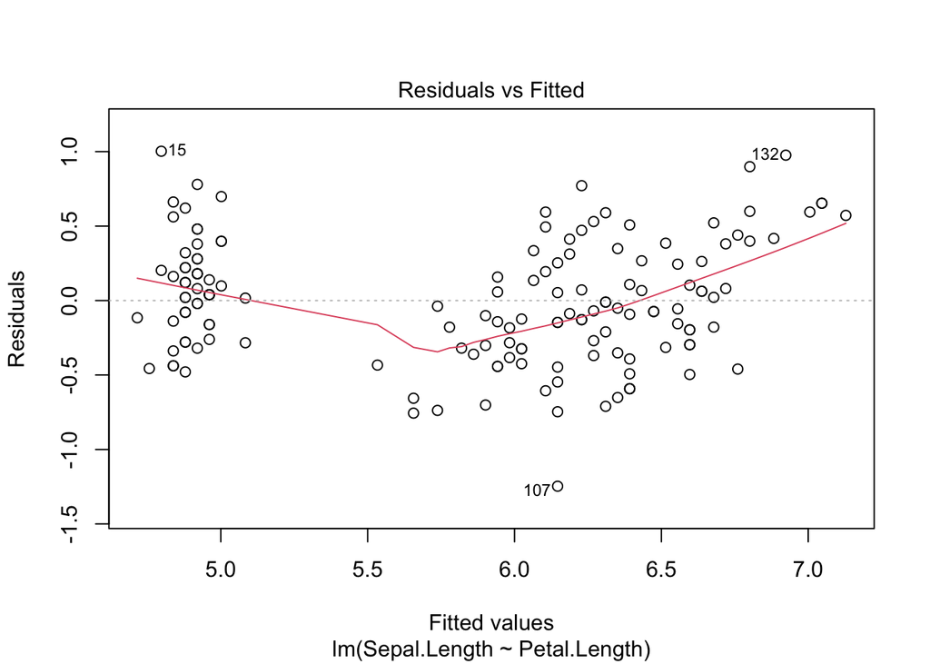

```r
# Residual plots are starting points for evaluating a model.
plot(model, which = 1)  # residuals versus fitted values
```

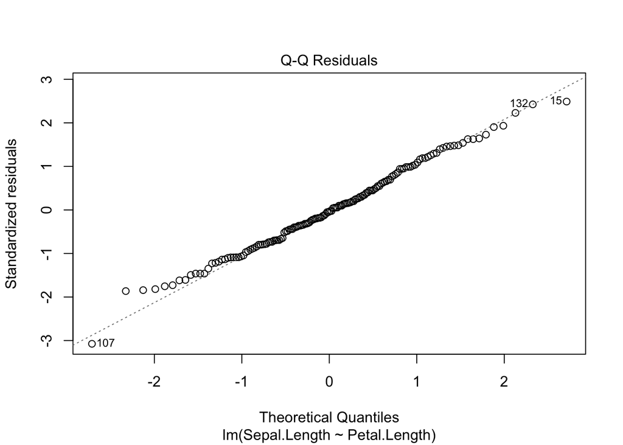

```r
plot(model, which = 2)  # residual Q-Q plot
```

The slope estimates a difference in mean sepal length per 1 cm higher petal length under this model. It is not a causal effect. A fitted line does not establish that assumptions are reasonable; examine diagnostics and the role of species before treating this as an adequate analysis.

### Read output with a purpose

| Output | Ask yourself |
| --- | --- |
| Estimate | How large is the observed difference or association, and in what units? |
| Confidence interval | What range is compatible with the data under the model? |
| P-value | How incompatible are these data with the specified null model and assumptions? |
| Sample size | Which observations actually contributed? |
| Diagnostics | Is this model a reasonable description of the data and design? |
| Practical meaning | Is the magnitude useful or consequential for this question? |

A p-value is not the probability that your hypothesis is true. A large p-value does not prove no effect. Report the magnitude and uncertainty, not just whether a threshold was crossed.

## Reliable guides: choose one for the next task

| Need | Resource | How to use it |
| --- | --- | --- |
| Organize an R project | [R for Data Science: scripts and projects](https://r4ds.hadley.nz/workflow-scripts.html) | Set up one project and practice a clean rerun |
| Explore before testing | [R for Data Science: exploratory data analysis](https://r4ds.hadley.nz/EDA.html) | Apply one question-and-plot cycle to your data |
| Understand statistical reasoning | [OpenIntro Statistics](https://www.openintro.org/book/os/) | Read the relevant inference section before choosing a test |
| Learn R’s statistical tools | [An Introduction to R](https://cran.r-project.org/doc/manuals/r-release/R-intro.html) | Use statistical model sections as a reference |
| Check t-test arguments and assumptions | [Official R: t.test](https://search.r-project.org/R/refmans/stats/html/t.test.html) | Compare independent and paired examples |
| Check correlation methods | [Official R: cor.test](https://search.r-project.org/R/refmans/stats/html/cor.test.html) | Review Pearson and Spearman details |
| Build toward modeling | [An Introduction to Statistical Learning](https://www.statlearning.com/) | Save for later; work through one R lab at a time |
| Combine code and narrative | [Quarto: using R](https://quarto.org/docs/computations/r.html) | Adapt an executable document to your own project |
| Ask a reproducible question | [R for Data Science: getting help](https://r4ds.hadley.nz/workflow-help.html) | Create a small example with data, packages, and code |

Use `?t.test`, `?cor.test`, or `?lm` inside R for the documentation corresponding to your installed version. These references support learning; the examples above are teaching illustrations rather than complete analysis protocols.

## When you get stuck

### A 15-minute reset

1. **Name the problem:** Is it the question, the data, the code, or the interpretation?
2. **Read the full message:** Start with the first error; later errors may be consequences.
3. **Shrink the problem:** Run one line and inspect the object with `str()`, `names()`, or `head()`.
4. **Check one explanation:** Object name, type, path, missingness, or package requirement.
5. **Save a help request:** Include a small reproducible example and your expected result.

If the problem remains after about 15 minutes, write down the blocker and switch to an independent task or ask for help. You do not have to solve every blocker alone.

| Symptom | First useful check |
| --- | --- |
| `object ... not found` | Run the chunk that creates it; check spelling and capitalization |
| `could not find function` | Check spelling and the package; use `package::function()` when appropriate |
| Cannot open a file | Check `getwd()` and `file.exists("data-raw/file.csv")` |
| A mean returns `NA` | Inspect missing values; decide how to handle them and report the denominator |
| Numbers behave like text | Run `str()`; look for units or symbols mixed into the column |
| Code works in Console but Render fails | Restart R and run top to bottom; check for hidden dependencies and file paths |
| A plot or result seems implausible | Check units, grouping, filters, joins, and duplicate keys before changing the method |

If using AI for help, ask it to explain each change, use a small example, and identify assumptions. Run the code and verify outputs yourself. Use synthetic or approved data when seeking help; do not paste confidential records into public tools.

## Keep momentum without making the project bigger

### The 30-minute work session

| Minutes | Action |
| --- | --- |
| 0–3 | Read your last note; choose one concrete outcome |
| 3–23 | Work on that outcome; keep useful code in the QMD |
| 23–28 | Run from the top and explain what changed |
| 28–30 | Save; record your next action and any blocker |

### My progress log

Copy a row after each work session. Track outputs and understanding rather than only time spent.

| Date | Intended task | What I produced or learned | Blocker | Exact next action |
| --- | --- | --- | --- | --- |
| *Date* | *Make a summary* | *Counts checked; group table saved* | *Unsure how to show missingness* | *Count missing values by group* |

### My decision log

| Decision | Reason | Consequence to report |
| --- | --- | --- |
| *Example: excluded rows missing the outcome* | *Outcome required for this summary* | *State number excluded; discuss potential bias* |

### A suggested four-week path

Adapt this to your schedule. Two focused sessions per week can be enough for a small first project.

| Week | Focus | Evidence of progress |
| --- | --- | --- |
| 1 | Define question, organize project, inspect data | Data dictionary and documented checks |
| 2 | Describe and visualize | One table, one plot, and plain-language interpretation |
| 3 | Learn one needed method or improve the descriptive report | Method rationale and checks, or a clearer report |
| 4 | Reproduce, explain, and reflect | Fresh render and a short walkthrough for a peer |

If you miss a session, reduce the next task to something you can finish in 15 minutes. Repeated access or data barriers are reasons to choose a practice dataset, narrow the question, or get help.

## Finish a useful first version

- My question and unit of observation are explicit.
- The data source, variable definitions, and inclusion rules are documented.
- Missingness and any exclusions are counted and explained.
- The table and plot answer the same question.
- Any statistical method is justified by the design and its assumptions.
- My interpretation includes magnitude, uncertainty when applicable, and limits.
- I can restart R and render the document without relying on saved objects.
- I have recorded one next question for a later version.

**A useful next step is enough:** make one result you can reproduce, understand, and explain. Then build from there.